# Machine Learning Algorithm for Qualitative HAR of Weight Lifting Exercises

agrou

1 March 2017

## Executive Summary

**Question**: How well do they do it?

**Goal:** use data from accelerometers on the belt, forearm, arm, and dumbell of 6 participants, from training data set, and predict with the “classe” variable or other variables the maner in which the participants did the exercise. Also use the model to predict 20 different test cases.

**Steps:**

- Load and prepare data for analysis
- Use different models to train the data (classification trees, linear discriminent analysis and random forests)
- Test the models in 20 different cases

**Results** Fitting a random forest to the data gave better estimates for the prediction of the outcome, than a classification tree. Data processing and analysis followed instructions on the `References` section of this report.

## Background

Six young health participants were asked to perform one set of 10 repetitions of the Unilateral Dumbbell Biceps Curl in five different fashions: exactly according to the specification (Class A), throwing the elbows to the front (Class B), lifting the dumbbell only halfway (Class C), lowering the dumbbell only halfway (Class D) and throwing the hips to the front (Class E).

Read more: http://groupware.les.inf.puc-rio.br/har#weight_lifting_exercises#ixzz4ZyJOw3EZ

## Data Processing

**Read the data**

```r
file_train <- "https://d396qusza40orc.cloudfront.net/predmachlearn/pml-training.csv"
train <- read.csv(file_train, na.strings = c("", "NA"))
dim(train)
```

```
## [1] 19622   160
```

```r
file_test <- "https://d396qusza40orc.cloudfront.net/predmachlearn/pml-testing.csv"
test <- read.csv(file_test, na.strings = c("", "NA"))
dim(test)
```

```
## [1]  20 160
```

Both sets have 160 variables. The train set has 19622 observations and the test set has 20 observations.

```r
#Load required libraries
library(tidyverse)
library(caret)
library(rpart)
library(randomForest)
library(rattle)
library(rpart.plot)
```

**Clean the data**

```r
# percentage of missing data for each column in the data set
training <- train %>% select(which(colMeans(is.na(.)) < 0.5)) # get only the columns with less than 50% of missing values in the train set
testing <- test %>% select(which(colMeans(is.na(.)) < 0.5)) # get only the columns with less than 50% of missing values in the test set

dim(training); dim(testing) #dimensions of each data set
```

```
## [1] 19622    60
```

```
## [1] 20 60
```

After removing most missing values from the data sets, both training and testing data sets have 60 variables. `Training` has 19622 observations and `Testing`has 20 observations.

```r
str(training) #understand the structure of the data and which variables can be excluded for the data modelling purpose
```

According to [documentation](http://groupware.les.inf.puc-rio.br/public/papers/2013.Velloso.QAR-WLE.pdf) available for this subject, we can consider for this exercise variables that were used to predict performance of the participants exercise. Thus we exclude the first variables in each data set.

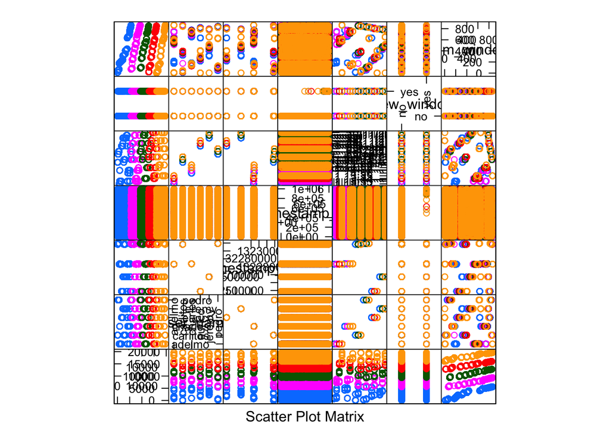

```r
xnames <- colnames(training)[1:7] #select first 7 variables from the training set
featurePlot(x = training[, xnames], y = training$classe, plot = "pairs") #The feature plot confirms little predictive power from these variables in the class outcome variable.
```

```r
mytrain <- training[!names(training) %in% xnames] # remove first variables from training data
mytest <- testing[!names(testing) %in% xnames] # remove first variables from testing data

dim(mytrain)
```

```
## [1] 19622    53
```

```r
dim(mytest)
```

```
## [1] 20 53
```

## Exploratory data analysis

```r
# Understand the outcome variable distribution
Count <- table(mytrain$classe)
Frequency <- paste(round((Count) / length(mytrain$classe) * 100), "%", sep ="")
pander::pander(rbind(Count, Frequency))
```

|  | A | B | C | D | E |
| --- | --- | --- | --- | --- | --- |
| **Count** | 5580 | 3797 | 3422 | 3216 | 3607 |
| **Frequency** | 28% | 19% | 17% | 16% | 18% |

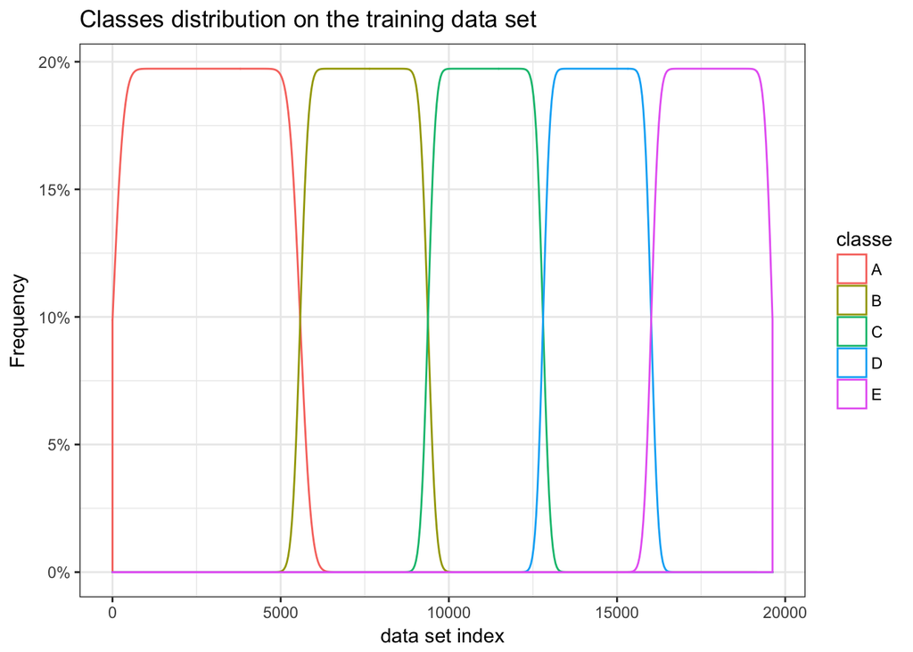

```r
library(scales)
index <- seq_along(1:nrow(mytrain))
ggplot(data = mytrain, aes(x = index, colour = classe)) + geom_density(aes(y = ..count../sum(..count..) *
    100)) + # geom_text(aes(y = ..count../sum(..count..) * 100), label =
# ..count../sum(..count..) * 100) +
scale_y_continuous(labels = scales::percent) + labs(title = "Classes distribution on the training data set",
    y = "Frequency", x = "data set index") + theme_bw()
```

More counts are expected for classe A and a balanced number of occurencies for the other classes.

## Machine Learning

**Data partition**

Next, `mytrain` is splitted 70% into a training set and 30% for testing set, to avoid sampling errors when predicting the outcome.

```r
# set the seed for reproducibility of the analysis
set.seed(12345)
inTrain <- createDataPartition(mytrain$classe, p = 0.7,
                               list = FALSE)
toTrain <- mytrain[inTrain, ]
toTest <- mytrain[-inTrain,] # the remaining 30% of data training data appended to testing data
```

**Train the data with prediction algorithms**

Since logist regression is applied to 2 class outcomes, we can fit a classification tree, a linear discriminent analysis (lda) and a random forest predictor relating the factor variable `classe` to the remaining variables.

First we fit a classification tree with cross validation and pre-processing.

```r
# fit rpart model
control <- trainControl(method = "cv", number = 5) #apply cross validation
rpart_model <- train(classe ~ ., data = toTrain, method = "rpart", trControl = control)
rpart_model
```

```
## CART
##
## 13737 samples
##    52 predictor
##     5 classes: 'A', 'B', 'C', 'D', 'E'
##
## No pre-processing
## Resampling: Cross-Validated (5 fold)
## Summary of sample sizes: 10989, 10990, 10990, 10989, 10990
## Resampling results across tuning parameters:
##
##   cp          Accuracy   Kappa
##   0.03753433  0.5161240  0.37284078
##   0.05987862  0.4166831  0.20949558
##   0.11585800  0.3323882  0.07355105
##
## Accuracy was used to select the optimal model using  the largest value.
## The final value used for the model was cp = 0.03753433.
```

```r
rpart_model2 <- train(classe ~ ., data = toTrain, method = "rpart", preProcess = c("center", "scale")) #apply preprocessing to analyse differences in the accuracy of the model
rpart_model2
```

```
## CART
##
## 13737 samples
##    52 predictor
##     5 classes: 'A', 'B', 'C', 'D', 'E'
##
## Pre-processing: centered (52), scaled (52)
## Resampling: Bootstrapped (25 reps)
## Summary of sample sizes: 13737, 13737, 13737, 13737, 13737, 13737, ...
## Resampling results across tuning parameters:
##
##   cp          Accuracy   Kappa
##   0.03753433  0.5135957  0.36893849
##   0.05987862  0.3812312  0.15135221
##   0.11585800  0.3226947  0.05976988
##
## Accuracy was used to select the optimal model using  the largest value.
## The final value used for the model was cp = 0.03753433.
```

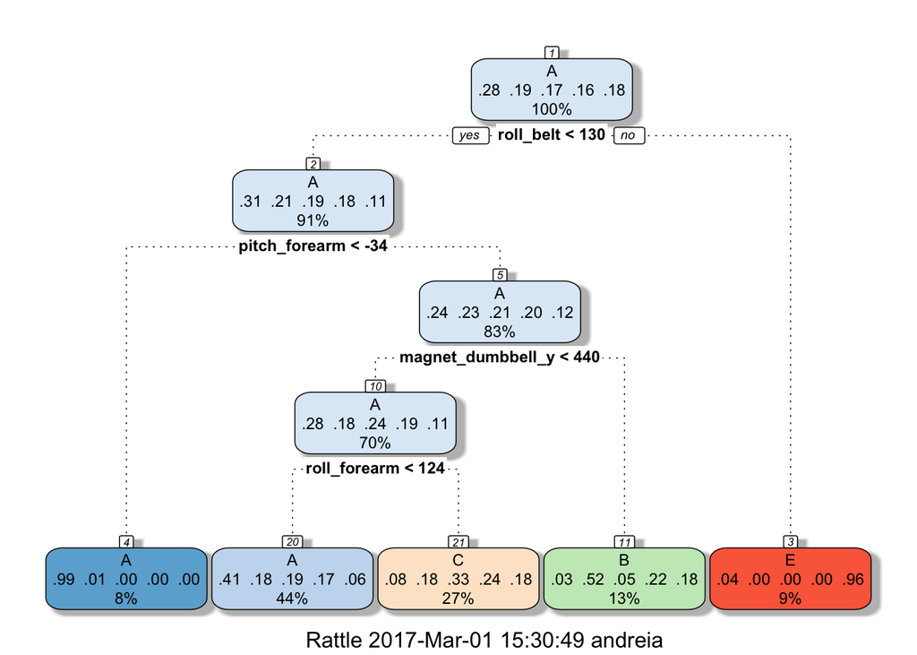

```r
# Plot classification tree
fancyRpartPlot(rpart_model$finalModel, palettes=c("Blues", "Greens"))
```

Accuracy is not different between pre-processing and cross-validation methods.

```r
# Predict the outcome using the test set
rpart_pred <- predict(rpart_model, toTest)
# Show prediction result
rpart_cm <- confusionMatrix(toTest$classe, rpart_pred)
rpart_cm
```

```
## Confusion Matrix and Statistics
##
##           Reference
## Prediction    A    B    C    D    E
##          A 1494   21  128    0   31
##          B  470  380  289    0    0
##          C  467   29  530    0    0
##          D  438  184  342    0    0
##          E  141  147  277    0  517
##
## Overall Statistics
##
##                Accuracy : 0.4963
##                  95% CI : (0.4835, 0.5092)
##     No Information Rate : 0.5115
##     P-Value [Acc > NIR] : 0.9902
##
##                   Kappa : 0.3425
##  Mcnemar's Test P-Value : NA
##
## Statistics by Class:
##
##                      Class: A Class: B Class: C Class: D Class: E
## Sensitivity            0.4963  0.49934  0.33844       NA  0.94343
## Specificity            0.9374  0.85187  0.88516   0.8362  0.89414
## Pos Pred Value         0.8925  0.33363  0.51657       NA  0.47782
## Neg Pred Value         0.6400  0.91972  0.78679       NA  0.99355
## Prevalence             0.5115  0.12931  0.26610   0.0000  0.09312
## Detection Rate         0.2539  0.06457  0.09006   0.0000  0.08785
## Detection Prevalence   0.2845  0.19354  0.17434   0.1638  0.18386
## Balanced Accuracy      0.7169  0.67561  0.61180       NA  0.91878
```

When testing the model in the testing part of the data, the accuracy rate of the classification tree is not very good to predict the outcome `classe`. Notice no prediction for class D. Thus we can apply another method.

Secondly we can fit a linear discriminent analysis

```r
# linear discriminent analysis
lda_model <- train(classe ~ ., data = toTrain, method = "lda", preProcess = c("center", "scale"))
lda_pred <- predict(lda_model, toTest) #predict in the testing part of the data set
lda_cm <- confusionMatrix(toTest$classe, lda_pred) #get the estimates for the analysis
lda_cm
```

```
## Confusion Matrix and Statistics
##
##           Reference
## Prediction    A    B    C    D    E
##          A 1380   36  133  116    9
##          B  191  709  142   43   54
##          C   91  104  658  144   29
##          D   48   49  125  698   44
##          E   38  193   99  100  652
##
## Overall Statistics
##
##                Accuracy : 0.6962
##                  95% CI : (0.6842, 0.7079)
##     No Information Rate : 0.297
##     P-Value [Acc > NIR] : < 2.2e-16
##
##                   Kappa : 0.6155
##  Mcnemar's Test P-Value : < 2.2e-16
##
## Statistics by Class:
##
##                      Class: A Class: B Class: C Class: D Class: E
## Sensitivity            0.7895   0.6499   0.5687   0.6340   0.8274
## Specificity            0.9289   0.9103   0.9222   0.9444   0.9156
## Pos Pred Value         0.8244   0.6225   0.6413   0.7241   0.6026
## Neg Pred Value         0.9126   0.9195   0.8973   0.9181   0.9717
## Prevalence             0.2970   0.1854   0.1966   0.1871   0.1339
## Detection Rate         0.2345   0.1205   0.1118   0.1186   0.1108
## Detection Prevalence   0.2845   0.1935   0.1743   0.1638   0.1839
## Balanced Accuracy      0.8592   0.7801   0.7454   0.7892   0.8715
```

The sensitivity and the accuracy improved with this model, but it is still worth to try to fit a Random forest

```r
# fit a Random forest
set.seed(12345)
rf_model <- randomForest(classe ~ . , data = toTrain)
```

```r
# test the Random forest model in the test set originated from data partition
rf_pred <- predict(rf_model, newdata = toTest)
table(rf_pred) # outcome predictions with random forest model
```

```
## rf_pred
##    A    B    C    D    E
## 1683 1137 1032  956 1077
```

```r
table(toTest$classe) # outcome in testing part of the data set
```

```
##
##    A    B    C    D    E
## 1674 1139 1026  964 1082
```

```r
rf_cm <- confusionMatrix(rf_pred, toTest$classe)
rf_cm
```

```
## Confusion Matrix and Statistics
##
##           Reference
## Prediction    A    B    C    D    E
##          A 1673   10    0    0    0
##          B    1 1126   10    0    0
##          C    0    3 1015   14    0
##          D    0    0    1  950    5
##          E    0    0    0    0 1077
##
## Overall Statistics
##
##                Accuracy : 0.9925
##                  95% CI : (0.99, 0.9946)
##     No Information Rate : 0.2845
##     P-Value [Acc > NIR] : < 2.2e-16
##
##                   Kappa : 0.9905
##  Mcnemar's Test P-Value : NA
##
## Statistics by Class:
##
##                      Class: A Class: B Class: C Class: D Class: E
## Sensitivity            0.9994   0.9886   0.9893   0.9855   0.9954
## Specificity            0.9976   0.9977   0.9965   0.9988   1.0000
## Pos Pred Value         0.9941   0.9903   0.9835   0.9937   1.0000
## Neg Pred Value         0.9998   0.9973   0.9977   0.9972   0.9990
## Prevalence             0.2845   0.1935   0.1743   0.1638   0.1839
## Detection Rate         0.2843   0.1913   0.1725   0.1614   0.1830
## Detection Prevalence   0.2860   0.1932   0.1754   0.1624   0.1830
## Balanced Accuracy      0.9985   0.9931   0.9929   0.9921   0.9977
```

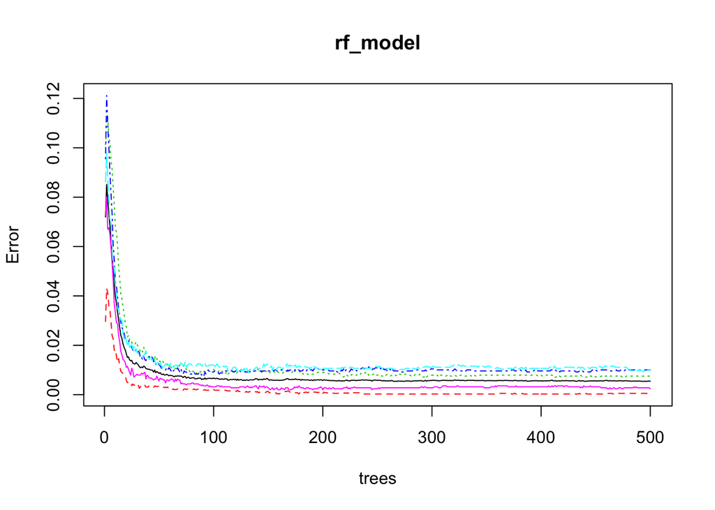

```r
plot(rf_model)
```

Random forests fit a better model to predict the outcome (activity), with better accuracy and sensitivity. The expected out-of-sample error is the remanescent `100-99.2 = 0.8%`.

===============================================================================

## Course Project Prediction Quiz Portion

Apply the machine learning algorithm to the 20 test cases available in the test data and submit the predictions to the Course Project Prediction Quiz for automated grading

## Prediction on 20 test cases

We can predict performance (the outcome `classe`) on the 20 cases available on the test data set.

```r
predict(rf_model, mytest)
```

```
##  1  2  3  4  5  6  7  8  9 10 11 12 13 14 15 16 17 18 19 20
##  B  A  B  A  A  E  D  B  A  A  B  C  B  A  E  E  A  B  B  B
## Levels: A B C D E
```

## References

The data for this project came from this source: http://groupware.les.inf.puc-rio.br/har.

Velloso, E.; Bulling, A.; Gellersen, H.; Ugulino, W.; Fuks, H. Qualitative Activity Recognition of Weight Lifting Exercises. Proceedings of 4th International Conference in Cooperation with SIGCHI (Augmented Human ’13) . Stuttgart, Germany: ACM SIGCHI, 2013.

Read more: http://groupware.les.inf.puc-rio.br/har#wle_paper_section#ixzz4ZtZIkJHv

```r
# count the words by adding a new Addin to Rstudio
devtools::install_github("benmarwick/wordcountaddin", type = "source", dependencies = TRUE)
```